# A very basic introduction to R

R for Political Science Grad Students course 2024-25

Author

Saar Alon-Barkat

Published

May 1, 2025

This file is a Quarto script file.

# 1. R is a smart calculator.

```r
1+1
```

```
[1] 2
```

```r
4*4
```

```
[1] 16
```

```r
0.5^2
```

```
[1] 0.25
```

```r
sqrt(0.25)
```

```
[1] 0.5
```

```r
log(2)
```

```
[1] 0.6931472
```

```r
rnorm(10)#rnorm represent a sample of n values from a normal distribution (by default mean=0 and SD=1).
```

```
 [1] -1.4033431  0.5498035  0.3471270  0.5011957  0.5434018 -1.3457106
 [7] -0.5383517 -1.0432213 -1.0786566  1.3353186
```

# 2. R has “objects”.

You can create and name “objects” and they will be saved in your “environment”. To create an “object” use the sign “<-”

```r
my_first_object <- 1
```

From now on, when you type “my_first_object” R will read the value of it:

```r
my_first_object
```

```
[1] 1
```

Now try this:

```r
my_first_object + 2
```

```
[1] 3
```

You can also “override” objects:

```r
my_first_object <- my_first_object + 2

my_first_object
```

```
[1] 3
```

# 3. Vectors and data frames

Almost anything can be an object. For example, an object can be a single value, or a “vector” (series of values)

```r
my_first_vector <- c(1,2,3,4,5,6,7,8,9,10)

my_second_vector <- c("a","b","c","a","b","c","a","b","c","x")

my_third_vector <- c(TRUE,TRUE,FALSE,FALSE,TRUE,TRUE,TRUE,FALSE,FALSE,TRUE)
#Notice how c() is used to represent a series of values.

my_fourth_vector <- rnorm(10)

my_fifth_vector <- 0.5*my_fourth_vector + rnorm(10,mean=0,sd=0.5)



my_first_vector
```

```
 [1]  1  2  3  4  5  6  7  8  9 10
```

```r
my_second_vector
```

```
 [1] "a" "b" "c" "a" "b" "c" "a" "b" "c" "x"
```

```r
my_third_vector
```

```
 [1]  TRUE  TRUE FALSE FALSE  TRUE  TRUE  TRUE FALSE FALSE  TRUE
```

```r
my_fourth_vector
```

```
 [1]  0.02567756 -0.98027521  1.41258421  1.34898852 -2.11138104 -0.82552757
 [7] -0.53628604 -0.33536781  1.07775779 -0.20396208
```

```r
my_fifth_vector
```

```
 [1] -0.76945952 -1.04616771  0.94887716 -0.42487316 -1.12502763  0.21639907
 [7]  0.02964918  0.24829753  0.73644281  1.30336291
```

Another important type of object is a data table, called “data frame”.

```r
my_first_dataframe <- data.frame(my_first_vector,
                                 my_second_vector,
                                 my_third_vector,
                                 my_fourth_vector,
                                 my_fifth_vector)
my_first_dataframe
```

```
   my_first_vector my_second_vector my_third_vector my_fourth_vector
1                1                a            TRUE       0.02567756
2                2                b            TRUE      -0.98027521
3                3                c           FALSE       1.41258421
4                4                a           FALSE       1.34898852
5                5                b            TRUE      -2.11138104
6                6                c            TRUE      -0.82552757
7                7                a            TRUE      -0.53628604
8                8                b           FALSE      -0.33536781
9                9                c           FALSE       1.07775779
10              10                x            TRUE      -0.20396208
   my_fifth_vector
1      -0.76945952
2      -1.04616771
3       0.94887716
4      -0.42487316
5      -1.12502763
6       0.21639907
7       0.02964918
8       0.24829753
9       0.73644281
10      1.30336291
```

In a data frame, each column is a “variable” and each row is an “observation”.

To extract a variable of a data frame you can use the $ sign:

```r
my_first_dataframe$my_first_vector
```

```
 [1]  1  2  3  4  5  6  7  8  9 10
```

Here is another way to do that:

```r
my_first_dataframe[,"my_first_vector"]
```

```
 [1]  1  2  3  4  5  6  7  8  9 10
```

And here is another way:

```r
my_first_dataframe[,1]
```

```
 [1]  1  2  3  4  5  6  7  8  9 10
```

The [,] structure enables you to extract an observation, and also a specific value of observation on a specific variable:

```r
my_first_dataframe[1,]
```

```
  my_first_vector my_second_vector my_third_vector my_fourth_vector
1               1                a            TRUE       0.02567756
  my_fifth_vector
1      -0.7694595
```

```r
my_first_dataframe[1,1]
```

```
[1] 1
```

Now try these and see what happens:

```r
my_first_dataframe[1,1:2]
```

```
  my_first_vector my_second_vector
1               1                a
```

```r
my_first_dataframe[1:2,c(1,3)]
```

```
  my_first_vector my_third_vector
1               1            TRUE
2               2            TRUE
```

# 4. Data types

There are three main data types:

1. Numerics (numerics/integers/doubles). (Data represent numeric values)
2. Characters. (Such as text. Data does not represent numeric value)
3. Logicals (TRUE/FALSE)

Data frames typically consist of different types of variable.

One of the great things about R is that you can work with endless data frames (and other objects) at the same time (by comparison with other software).

```r
gapminder = read.csv("https://raw.githubusercontent.com/saaralonbarkat/r-poliscience-grad-students-course-/refs/heads/main/data/gapminder/gapminder.csv")


head(gapminder)
```

```
      country continent year lifeExp      pop gdpPercap
1 Afghanistan      Asia 1952  28.801  8425333  779.4453
2 Afghanistan      Asia 1957  30.332  9240934  820.8530
3 Afghanistan      Asia 1962  31.997 10267083  853.1007
4 Afghanistan      Asia 1967  34.020 11537966  836.1971
5 Afghanistan      Asia 1972  36.088 13079460  739.9811
6 Afghanistan      Asia 1977  38.438 14880372  786.1134
```

You will later learn how to import data files from your computer. Noteworthy that R can also import all data types (csv, xls, dta, sav…).

# 5. Basic operators

R has operators. We will get to know some of them.

‘==’ means “equal”

```r
1+2==2+1
```

```
[1] TRUE
```

```r
3+2==2+1
```

```
[1] FALSE
```

```r
my_first_dataframe$my_second_vector=="a"
```

```
 [1]  TRUE FALSE FALSE  TRUE FALSE FALSE  TRUE FALSE FALSE FALSE
```

‘!=’ means “not equal”

```r
3+2!=2+1
```

```
[1] TRUE
```

‘|’ means “or”

```r
my_first_dataframe[1,2]=="b"|my_first_dataframe[1,2]=="c"
```

```
[1] FALSE
```

```r
#You can also use the %in% operator:
my_first_dataframe[1,2] %in% c("b","c")
```

```
[1] FALSE
```

‘>’,‘<’,‘<=’,‘>=’ greater / smaller than signs

```r
my_first_dataframe$my_fourth_vector >= 0
```

```
 [1]  TRUE FALSE  TRUE  TRUE FALSE FALSE FALSE FALSE  TRUE FALSE
```

Let’s use the `==` operator to filter the data (next meeting we will learn other ways to do it):

```r
gapminder_2007 <- gapminder[gapminder$year==2007,]
```

# 5. Functions and packages

R has multiple built-in functions. Here are some examples:

```r
round(1.168)
```

```
[1] 1
```

```r
mean(gapminder_2007$lifeExp) # Mean of a variable
```

```
[1] 67.00742
```

```r
table(gapminder_2007$continent) # Frequency table
```

```
  Africa Americas     Asia   Europe  Oceania
      52       25       33       30        2
```

```r
summary(gapminder_2007)
```

```
   country           continent              year         lifeExp
 Length:142         Length:142         Min.   :2007   Min.   :39.61
 Class :character   Class :character   1st Qu.:2007   1st Qu.:57.16
 Mode  :character   Mode  :character   Median :2007   Median :71.94
                                       Mean   :2007   Mean   :67.01
                                       3rd Qu.:2007   3rd Qu.:76.41
                                       Max.   :2007   Max.   :82.60
      pop              gdpPercap
 Min.   :1.996e+05   Min.   :  277.6
 1st Qu.:4.508e+06   1st Qu.: 1624.8
 Median :1.052e+07   Median : 6124.4
 Mean   :4.402e+07   Mean   :11680.1
 3rd Qu.:3.121e+07   3rd Qu.:18008.8
 Max.   :1.319e+09   Max.   :49357.2
```

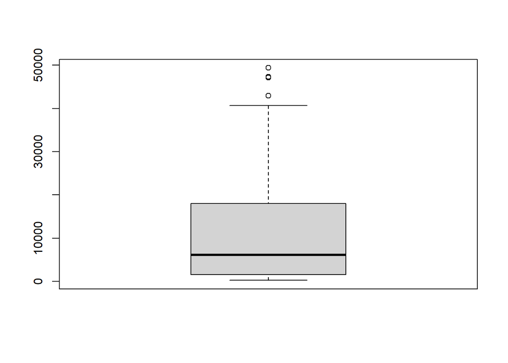

```r
boxplot(gapminder_2007$gdpPercap)
```

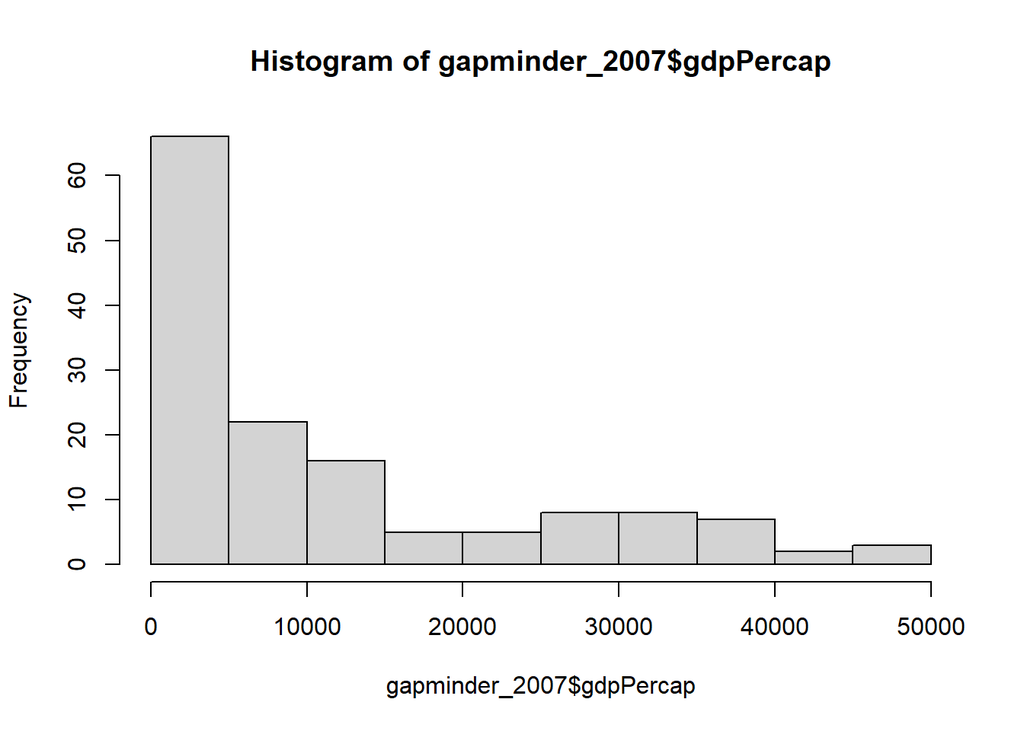

```r
hist(gapminder_2007$gdpPercap)
```

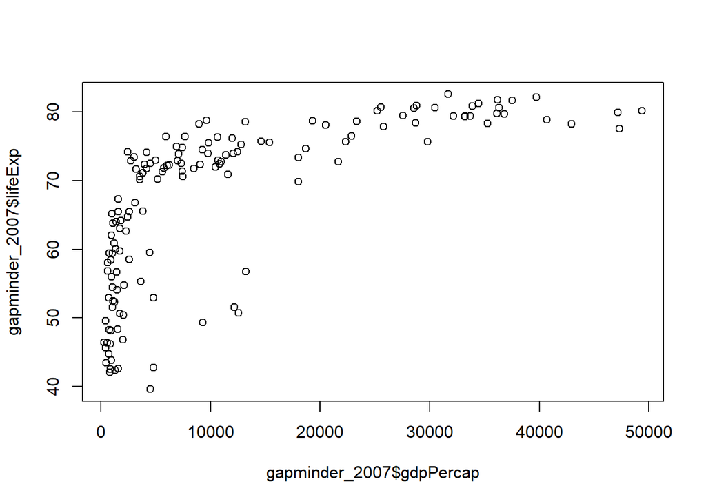

```r
plot(gapminder_2007$gdpPercap,gapminder_2007$lifeExp)
```

```r
cor.test(gapminder_2007$gdpPercap,gapminder_2007$lifeExp) # Correlation coefficient test
```

```
    Pearson's product-moment correlation

data:  gapminder_2007$gdpPercap and gapminder_2007$lifeExp
t = 10.933, df = 140, p-value < 2.2e-16
alternative hypothesis: true correlation is not equal to 0
95 percent confidence interval:
 0.5786217 0.7585843
sample estimates:
      cor
0.6786624
```

```r
model1 <- lm(lifeExp~gdpPercap,data=gapminder_2007) # Linear OLS regression model
summary(model1)
```

```
Call:
lm(formula = lifeExp ~ gdpPercap, data = gapminder_2007)

Residuals:
    Min      1Q  Median      3Q     Max
-22.828  -6.316   1.922   6.898  13.128

Coefficients:
             Estimate Std. Error t value Pr(>|t|)
(Intercept) 5.957e+01  1.010e+00   58.95   <2e-16 ***
gdpPercap   6.371e-04  5.827e-05   10.93   <2e-16 ***
---
Signif. codes:  0 '***' 0.001 '**' 0.01 '*' 0.05 '.' 0.1 ' ' 1

Residual standard error: 8.899 on 140 degrees of freedom
Multiple R-squared:  0.4606,    Adjusted R-squared:  0.4567
F-statistic: 119.5 on 1 and 140 DF,  p-value: < 2.2e-16
```

```r
# Notice that `summary` and `plot` are versatile functions. They do different things depending on the type of data.
```

These ready to use functions are called “base R” functions.

R also let’s you create your own functions. e.g. - this very basic function will extract the sum of two numbers

```r
myfunction <- function(x,y){
  z = x+y
  print(z)
  }

myfunction(2,4)
```

```
[1] 6
```

But, one of the things that are great in R is that there are endless extensions that you can download (like apps in your smartphone). These extensions are called “packages” or “libraries”.

# 6. Tidyverse

We will work with the very useful set of packages in “tidyverse”. In the first time you are using a package you need to download and install it with `install.packages`

```r
#install.packages("tidyverse")
```

Then, you need to open it - and it is ready.

```r
library(tidyverse)
```

Tidyverse is a set of packages that provide solutions to all of the stages in the data workflow (import, tidy, transform, visualize, model, communicate).

It uses a unified simple, intuitive human language where functions are verbs.

For example, instead of `gapminder_2007 <- gapminder[gapminder$year==2007,]` - you can write:

```r
gapminder %>%
  filter(year==2007)
```

```
                     country continent year lifeExp        pop  gdpPercap
1                Afghanistan      Asia 2007  43.828   31889923   974.5803
2                    Albania    Europe 2007  76.423    3600523  5937.0295
3                    Algeria    Africa 2007  72.301   33333216  6223.3675
4                     Angola    Africa 2007  42.731   12420476  4797.2313
5                  Argentina  Americas 2007  75.320   40301927 12779.3796
6                  Australia   Oceania 2007  81.235   20434176 34435.3674
7                    Austria    Europe 2007  79.829    8199783 36126.4927
8                    Bahrain      Asia 2007  75.635     708573 29796.0483
9                 Bangladesh      Asia 2007  64.062  150448339  1391.2538
10                   Belgium    Europe 2007  79.441   10392226 33692.6051
11                     Benin    Africa 2007  56.728    8078314  1441.2849
12                   Bolivia  Americas 2007  65.554    9119152  3822.1371
13    Bosnia and Herzegovina    Europe 2007  74.852    4552198  7446.2988
14                  Botswana    Africa 2007  50.728    1639131 12569.8518
```

[output cut: 128 more lines]

```r
gapminder %>%
  filter(year==2007)%>%
  head()
```

```
      country continent year lifeExp      pop  gdpPercap
1 Afghanistan      Asia 2007  43.828 31889923   974.5803
2     Albania    Europe 2007  76.423  3600523  5937.0295
3     Algeria    Africa 2007  72.301 33333216  6223.3675
4      Angola    Africa 2007  42.731 12420476  4797.2313
5   Argentina  Americas 2007  75.320 40301927 12779.3796
6   Australia   Oceania 2007  81.235 20434176 34435.3674
```

```r
gapminder_2007 %>%
  arrange(lifeExp)%>%
  head()
```

```
       country continent year lifeExp      pop gdpPercap
1    Swaziland    Africa 2007  39.613  1133066 4513.4806
2   Mozambique    Africa 2007  42.082 19951656  823.6856
3       Zambia    Africa 2007  42.384 11746035 1271.2116
4 Sierra Leone    Africa 2007  42.568  6144562  862.5408
5      Lesotho    Africa 2007  42.592  2012649 1569.3314
6       Angola    Africa 2007  42.731 12420476 4797.2313
```

The `%\>%` operator is called “pipe”. It is an important element in Tidyverse and it is extremely useful. It makes tidyverse code very elegant - intuitive and easy to read, understand and learn. Last year, R also implemented a “base pipe” that can also work: `|>`. So you can either use `%>%` or `|>`

```r
gapminder %>%
  filter(year==2007) %>%
  select(continent,country,lifeExp) %>%
  arrange(lifeExp)
```

```
    continent                  country lifeExp
1      Africa                Swaziland  39.613
2      Africa               Mozambique  42.082
3      Africa                   Zambia  42.384
4      Africa             Sierra Leone  42.568
5      Africa                  Lesotho  42.592
6      Africa                   Angola  42.731
7      Africa                 Zimbabwe  43.487
8        Asia              Afghanistan  43.828
9      Africa Central African Republic  44.741
10     Africa                  Liberia  45.678
11     Africa                   Rwanda  46.242
12     Africa            Guinea-Bissau  46.388
13     Africa         Congo, Dem. Rep.  46.462
14     Africa                  Nigeria  46.859
```

[output cut: 128 more lines]

We will often use tidyverse in the course. We recommend you to get used to working with it (but you prefer to use base R that’s also ok). In the end you will develop your own habits and coding style.